# Week 2: Detecting doublets with scDblFinder

Kevin Z. Lin

2026-08-03

# 1 Overview

This overview was made from the scDblFinder vignette, https://plger.github.io/scDblFinder/articles/scDblFinder.html, and the accompanying paper (Germain *et al.*, F1000Research 2022).

The SoupX tutorials dealt with mRNA that ended up in the wrong droplet. This one deals with a coarser problem: **two whole cells ending up in the same droplet.**

Droplet protocols work by diluting cells enough that most droplets get either one cell or none. “Most” is doing a lot of work in that sentence. A droplet that captures two cells produces one barcode, one apparent transcriptome, and one row in your final matrix — a cell that does not exist, whose expression profile is the sum of two real ones. The rate is not negligible: it scales with how many cells you load, and 10–20% is common in experiments that push for high cell numbers.

Some vocabulary, which the paper is careful about and which matters here:

- A **droplet** is whatever got assigned to one barcode, singlet or not.
- A **homotypic** doublet is two cells of the *same* type. It looks like a slightly larger cell of that type. These are nearly impossible to detect from expression alone — and mostly harmless, since they resemble what they are made of.
- A **heterotypic** doublet is two cells of *different* types. A T cell fused with a monocyte looks like neither. These are the dangerous ones: they can form their own cluster and be annotated as a novel intermediate cell type that does not exist.

**Every method in this space, including this one, targets heterotypic doublets.** That is the right priority, but you should know it is the deal being made: a clean doublet report does not mean there are no doublets, it means there are few detectable ones.

## 1.1 The idea

We cannot see which droplets are doublets. But we can *manufacture* doublets we know about: take two real droplets, add their counts together, and you have a synthetic doublet with a known label.

Do that thousands of times and you have a labelled training set. `scDblFinder` then builds a k-nearest-neighbour graph on the real droplets plus the artificial ones, and for each real droplet asks how much artificial-doublet company it keeps. Cells sitting in a neighbourhood dense with synthetic doublets are likely to be doublets themselves. Those neighbourhood statistics, along with library size and a few other features, are fed to a classifier.

One refinement is worth knowing because it explains a design choice you would otherwise find odd. The classifier is trained to separate *artificial* doublets from *real droplets* — but some of those real droplets are themselves doublets, mislabelled as singlets, which actively misleads the training. So the procedure is iterated: droplets confidently called as doublets are removed from the training data and it is refit. Three rounds by default.

# 2 Setting up

```r
# if (!require("BiocManager", quietly = TRUE)) install.packages("BiocManager")
# BiocManager::install("scDblFinder")
```

`scDblFinder` is a Bioconductor package rather than a CRAN one, so it installs through `BiocManager` instead of `install.packages()`.

```r
library(Seurat)
library(scDblFinder)
library(ggplot2)
```

```r
rm(list = ls())
```

# 3 Getting the data

We use the 10x **PBMC 1k** dataset — the same one as the first SoupX tutorial. Doublet detection itself needs only the called cells, but we also want CellRanger’s clustering and UMAP coordinates so that we can *look* at the doublets at the end, so we download the `analysis/` folder too.

```r
tmp_dir <- tempdir(check = TRUE)
base_url <- paste0("https://cf.10xgenomics.com/samples/cell-vdj/4.0.0/",
                   "sc5p_v2_hs_PBMC_1k/sc5p_v2_hs_PBMC_1k")

for (component in c("filtered_feature_bc_matrix", "analysis")) {
  destination <- file.path(tmp_dir, paste0(component, ".tar.gz"))
  download.file(paste0(base_url, "_", component, ".tar.gz"),
                destfile = destination)
  untar(destination, exdir = tmp_dir)
}
```

## 3.1 Borrowing CellRanger’s clusters and UMAP

We are not going to *use* the clusters for doublet detection — more on that choice below — but we want them, and the UMAP coordinates, so that the final result can be plotted. Computing a UMAP ourselves is Week 3’s material; CellRanger already did it, so we may as well read it off disk.

Both files are CSVs whose first column is the cell barcode. `row.names = 1` tells `read.csv()` to use that first column as row names rather than as data, which is exactly the format Seurat wants for attaching metadata to cells.

```r
clustering_df <- read.csv(file.path(tmp_dir, "analysis", "clustering",
                                    "graphclust", "clusters.csv"),
                          row.names = 1)
umap_df <- read.csv(file.path(tmp_dir, "analysis", "umap",
                              "2_components", "projection.csv"),
                    row.names = 1)
umap_df <- as.matrix(umap_df)

head(clustering_df)
```

```
##                    Cluster
## AAACCTGCAGCCTGTG-1       2
## AAACGGGTCGCTGATA-1       2
## AAAGATGTCCTCGCAT-1       2
## AAAGCAAAGTATGACA-1       1
## AAAGCAATCCATTCTA-1       3
## AAATGCCCACTTAAGC-1       1
```

```r
head(umap_df)
```

```
##                       UMAP.1     UMAP.2
## AAACCTGCAGCCTGTG-1 12.904839 -1.1254779
## AAACGGGTCGCTGATA-1 13.508979  0.3298732
## AAAGATGTCCTCGCAT-1  4.914615  1.3191117
## AAAGCAAAGTATGACA-1 12.914099  0.3939606
## AAAGCAATCCATTCTA-1  5.408821  0.9081023
## AAATGCCCACTTAAGC-1 11.030517  5.1262770
```

Note the `as.matrix()`. Seurat stores dimension reductions as matrices, not data frames, and will reject a data frame.

## 3.2 Reading the counts

```r
pbmc_data <- Seurat::Read10X(file.path(tmp_dir, "filtered_feature_bc_matrix"))
class(pbmc_data)
```

```
## [1] "list"
```

```r
names(pbmc_data)
```

```
## [1] "Gene Expression"  "Antibody Capture"
```

Here is a trap worth meeting deliberately. This dataset contains **two kinds of features** — 36,601 genes and 19 antibody-capture tags — so `Read10X()` does not return a matrix. It returns a *list* of two matrices, and prints a message saying so. Code written for a single matrix will fail here in confusing ways, or worse, silently analyze the wrong thing. We take the gene expression explicitly:

```r
pbmc <- Seurat::CreateSeuratObject(counts = pbmc_data[["Gene Expression"]],
                                   project = "pbmc1k",
                                   meta.data = clustering_df)
pbmc
```

```
## An object of class Seurat
## 36601 features across 972 samples within 1 assay
## Active assay: RNA (36601 features, 0 variable features)
##  1 layer present: counts
```

```r
head(pbmc@meta.data)
```

```
##                    orig.ident nCount_RNA nFeature_RNA Cluster
## AAACCTGCAGCCTGTG-1     pbmc1k       5029         1819       2
## AAACGGGTCGCTGATA-1     pbmc1k       4343         1738       2
## AAAGATGTCCTCGCAT-1     pbmc1k        898          554       2
## AAAGCAAAGTATGACA-1     pbmc1k       4999         1796       1
## AAAGCAATCCATTCTA-1     pbmc1k        601          416       3
## AAATGCCCACTTAAGC-1     pbmc1k       4998         1530       1
```

Passing `meta.data = clustering_df` attaches the cluster labels at construction. Seurat matches on row names, so each cell gets its own label regardless of the row order in the CSV.

Now the UMAP. A Seurat object keeps dimension reductions in a separate slot from metadata, so this needs its own step:

```r
pbmc[["umap"]] <- Seurat::CreateDimReducObject(umap_df,
                                               key = "UMAP_",
                                               assay = "RNA")
pbmc
```

```
## An object of class Seurat
## 36601 features across 972 samples within 1 assay
## Active assay: RNA (36601 features, 0 variable features)
##  1 layer present: counts
##  1 dimensional reduction calculated: umap
```

The `key` is the prefix Seurat gives the reduction’s columns, and it must end in an underscore — it becomes the axis labels when you plot, so `UMAP_` yields `UMAP_1` and `UMAP_2`.

# 4 Handing the data to Bioconductor

`scDblFinder` is a Bioconductor tool, and Bioconductor’s container for single-cell data is the `SingleCellExperiment`, not Seurat’s object. The two ecosystems hold the same information in different shapes, and moving between them is a routine chore you will do many times.

```r
Seurat::DefaultAssay(pbmc) <- "RNA"
```

Setting `DefaultAssay` first is a small piece of defensive hygiene. A Seurat object can hold several assays — raw RNA, SCTransform output, a SoupX-corrected matrix — and the conversion exports whichever is currently active. Being explicit means you know which matrix you just handed over.

One extra step is needed on **Seurat version 5**, which introduced a new internal assay format (`Assay5`) that the converter does not fully understand. Rewrapping the counts in the older `Assay` format avoids the problem:

```r
rna_counts <- Seurat::GetAssayData(pbmc[["RNA"]], layer = "counts")
pbmc[["RNA"]] <- Seurat::CreateAssayObject(counts = rna_counts)
```

This prints `Assay RNA changing from Assay5 to Assay`, which is the operation succeeding, not a problem. If you are on Seurat 4 you can skip this chunk entirely. Checking `packageVersion("Seurat")` will tell you which you have.

```r
sce <- Seurat::as.SingleCellExperiment(pbmc)
sce
```

```
## class: SingleCellExperiment
## dim: 36601 972
## metadata(0):
## assays(2): counts logcounts
## rownames(36601): MIR1302-2HG FAM138A ... AC007325.4 AC007325.2
## rowData names(0):
## colnames(972): AAACCTGCAGCCTGTG-1 AAACGGGTCGCTGATA-1 ...
##   TTTGTCAAGTCTCAAC-1 TTTGTCATCGCAAACT-1
## colData names(5): orig.ident nCount_RNA nFeature_RNA Cluster ident
## reducedDimNames(1): UMAP
## mainExpName: RNA
## altExpNames(0):
```

Look at what came across: the counts, the `Cluster` column in `colData`, and the UMAP in `reducedDims`. The two ecosystems really do hold the same information in different shapes.

`scDblFinder` works from the raw `counts` assay and does its own normalization and dimension reduction internally, so there is no need to normalize beforehand. You will notice the object also carries a `logcounts` assay — but since we never ran `NormalizeData()`, that is a copy of the raw counts rather than anything logged. Nothing downstream uses it here, but it is the kind of thing worth noticing rather than trusting by its name.

# 5 Running scDblFinder

Artificial doublets are generated at random, so the result changes slightly from run to run. `set.seed()` fixes that.

```r
set.seed(10)
sce_dbl <- scDblFinder::scDblFinder(sce, clusters = NULL)
```

`clusters = NULL` selects **random** artificial doublets: pairs of droplets are combined without regard to cell type.

Note that we loaded CellRanger’s clusters earlier and are now deliberately not using them. Having gone to the trouble, we could pass them — `scDblFinder(sce, clusters = sce$Cluster)` — which generates artificial doublets *between* clusters instead of at random.

It would be reasonable to assume the cluster-aware version is simply better. It is not. The paper benchmarks both and finds them very close, and the package’s own advice is to prefer the cluster-based approach only when your data segregates cleanly into clusters (or when you specifically want to know which cell types produced each doublet). When the structure is less crisp — which describes plenty of brain data — the random approach is the safer default. That is why it *is* the default, and it is what we use here. The clusters earn their keep in the visualization at the end instead.

# 6 Reading the output

The function returns the same object with new columns in `colData`. Two matter.

```r
head(sce_dbl$scDblFinder.score)
```

```
## [1] 0.020219747 0.002401070 0.002156684 0.006585793 0.001322535 0.012214868
```

```r
quantile(sce_dbl$scDblFinder.score)
```

```
##           0%          25%          50%          75%         100%
## 0.0001823068 0.0027260012 0.0093829525 0.0301912632 0.9997988343
```

`scDblFinder.score` runs from 0 to 1 and behaves like a probability of being a doublet — with the caveat, stated in the paper, that it is *not* calibrated to the underlying doublet rate, so do not read it as a literal posterior.

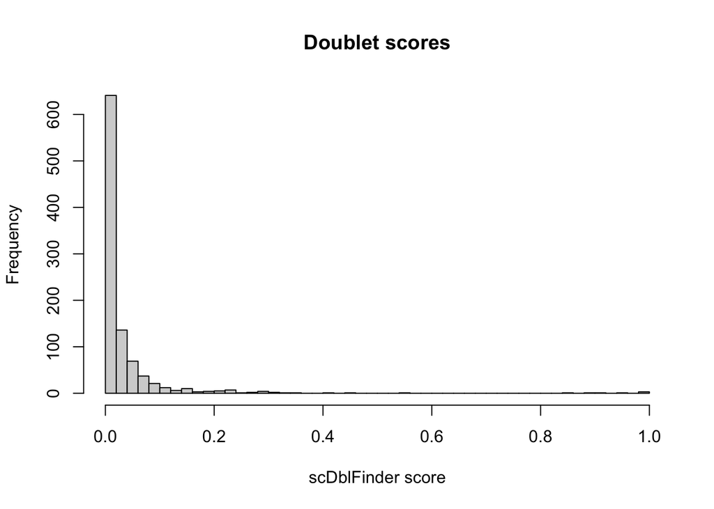

```r
hist(sce_dbl$scDblFinder.score,
     breaks = 50,
     main = "Doublet scores",
     xlab = "scDblFinder score")
```

The shape to hope for is a large pile near zero with a thin tail reaching towards one: most droplets confidently singlets, a minority confidently not. A flat or broadly-spread histogram would be a warning sign — it would mean the classifier could not separate the two populations, and any threshold drawn through it would be arbitrary.

`scDblFinder` also picks a threshold and gives you the call directly:

```r
table(sce_dbl$scDblFinder.class)
```

```
##
## singlet doublet
##     963       9
```

## 6.1 Where that threshold comes from

This is the part most worth understanding, because it is where an unexamined default can quietly cost you a lot of cells.

`scDblFinder` does not simply cut at a score of 0.5. It chooses a threshold that balances two objectives: misclassifying as few *artificial* doublets as possible, and landing near the number of doublets it *expects* the experiment to contain.

That expectation comes from the `dbr.per1k` argument, default **0.008** — 0.8% doublets per thousand cells captured, which is the standard 10x figure. This dataset has 972 cells, so the expectation is only `0.972 * 0.008` ≈ **0.8%**, which is about 8 droplets. Compare that with the table above.

That is a genuinely small number, and it is the honest consequence of a small capture rather than a shortcoming of the method. It also makes the scaling concrete: the same calculation on a 10,000-cell run would expect 8% doublets — a tenfold higher rate from the same chemistry, purely because more cells were loaded. If you are choosing how many cells to load, this is the trade-off you are making.

Two consequences follow, and both bite in practice:

- **The expected rate scales with cell count.** Load more cells, get proportionally more doublets. This is a property of the chemistry, not of your biology.
- **If your chemistry differs, change the argument.** 10x High Throughput chips use roughly half this rate (`dbr.per1k = 0.004`). If you have an independent estimate — from cell hashing or SNP demultiplexing — supply it directly with `dbr`.

> **Check your package version.** `scDblFinder` 1.20.0, which shipped with Bioconductor 3.20, had this default set to `0.08` rather than `0.008` — a tenfold overestimate of the doublet rate, and a large number of good cells thrown away. It was corrected in 1.20.2. `packageVersion("scDblFinder")` will tell you, and updating fixes it.

> **The single most common failure.** If `scDblFinder` calls an implausible number of doublets, the usual cause is a **multi-sample dataset run without the `samples` argument**. Handed 40,000 cells from ten captures, it assumes one enormous capture and infers a correspondingly enormous doublet rate. Doublets form *within* a capture, so the calculation must be per capture: `scDblFinder(sce, samples = "sample_id")`. This will apply to nearly everyone in this workshop with more than one sample.

# 7 Back to Seurat, and filtering

The scores live on the `SingleCellExperiment`. We copy them across to the Seurat object, which is where the rest of the analysis happens.

```r
pbmc$scDblFinder.score <- sce_dbl$scDblFinder.score
pbmc$scDblFinder.class <- sce_dbl$scDblFinder.class

head(pbmc@meta.data)
```

```
##                    orig.ident nCount_RNA nFeature_RNA Cluster scDblFinder.score
## AAACCTGCAGCCTGTG-1     pbmc1k       5029         1819       2       0.020219747
## AAACGGGTCGCTGATA-1     pbmc1k       4343         1738       2       0.002401070
## AAAGATGTCCTCGCAT-1     pbmc1k        898          554       2       0.002156684
## AAAGCAAAGTATGACA-1     pbmc1k       4999         1796       1       0.006585793
## AAAGCAATCCATTCTA-1     pbmc1k        601          416       3       0.001322535
## AAATGCCCACTTAAGC-1     pbmc1k       4998         1530       1       0.012214868
##                    scDblFinder.class
## AAACCTGCAGCCTGTG-1           singlet
## AAACGGGTCGCTGATA-1           singlet
## AAAGATGTCCTCGCAT-1           singlet
## AAAGCAAAGTATGACA-1           singlet
## AAAGCAATCCATTCTA-1           singlet
## AAATGCCCACTTAAGC-1           singlet
```

This works because both objects have the same cells in the same order — the conversion preserved it. That is worth checking rather than assuming whenever you move data between containers:

```r
all(colnames(pbmc) == colnames(sce_dbl))
```

```
## [1] TRUE
```

# 8 Looking at the doublets

This is what the UMAP was for. Until now the doublets have been a number in a table; plotting them tells you whether that number is believable.

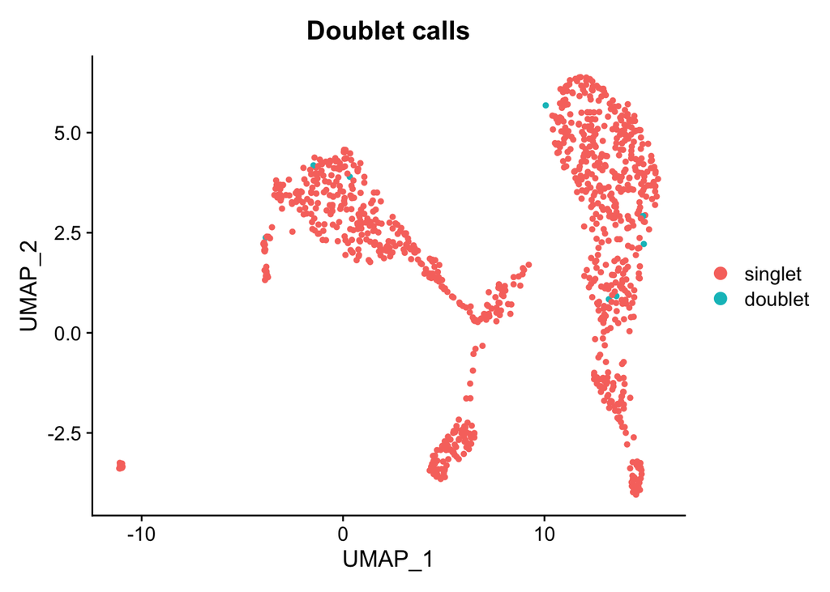

```r
Seurat::DimPlot(pbmc, group.by = "scDblFinder.class") +
  ggplot2::ggtitle("Doublet calls")
```

The question to ask is *where* the flagged droplets sit. Two patterns are reassuring and one is not:

- **Scattered at the edges of clusters, or in the gaps between them** — this is what you hope for, and it is what the method predicts. A heterotypic doublet is a mixture of two cell types, so it should land somewhere between the two clusters it was made from.
- **Concentrated in one small region** — worth investigating. It may be a genuine doublet-heavy island, in which case you have just avoided annotating an artifact as a novel cell type. That is the failure mode this whole exercise exists to prevent.
- **Spread uniformly across everything, including cluster cores** — a warning sign. Doublets should not be indistinguishable from the cells around them, and a diffuse pattern suggests the classifier found little real signal.

It is also worth seeing the scores themselves rather than the thresholded call, because the threshold hides how marginal some decisions were:

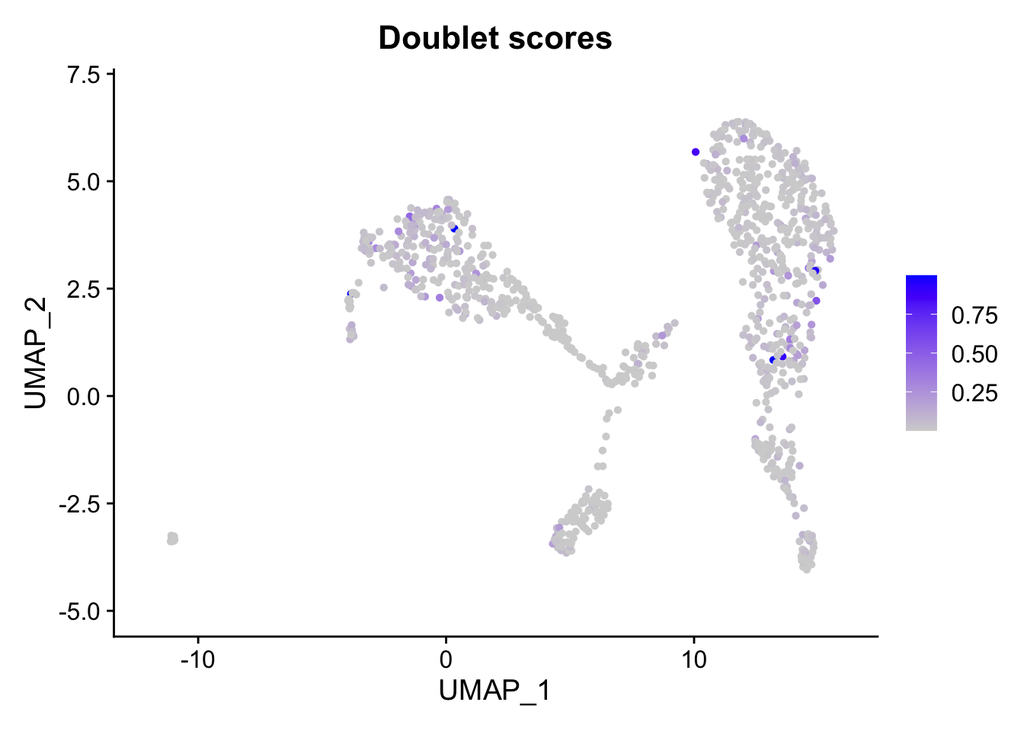

```r
Seurat::FeaturePlot(pbmc, features = "scDblFinder.score") +
  ggplot2::ggtitle("Doublet scores")
```

And against CellRanger’s clusters, to see whether any one population is contributing more than its share:

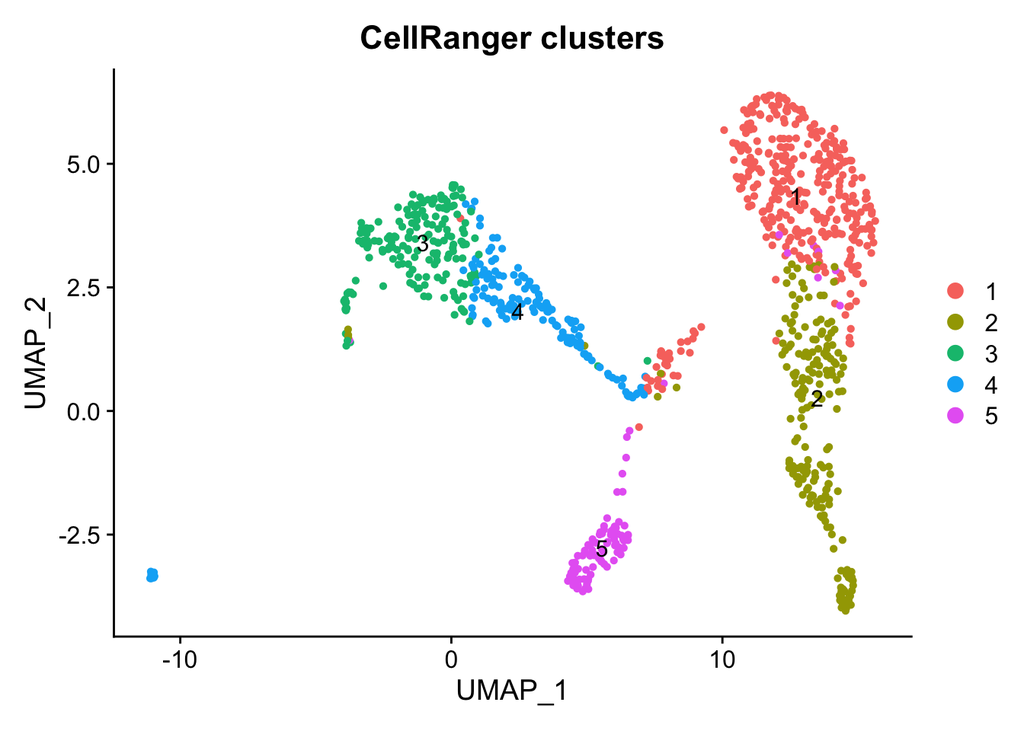

```r
Seurat::DimPlot(pbmc, group.by = "Cluster", label = TRUE) +
  ggplot2::ggtitle("CellRanger clusters")
```

# 9 Filtering, and the result

Now we drop the droplets called as doublets.

```r
pbmc <- subset(pbmc, scDblFinder.class == "singlet")
pbmc
```

```
## An object of class Seurat
## 36601 features across 963 samples within 1 assay
## Active assay: RNA (36601 features, 0 variable features)
##  2 layers present: counts, data
##  1 dimensional reduction calculated: umap
```

The UMAP coordinates were attached to the cells, so the reduction survives the subsetting — we can plot the retained singlets directly without recomputing anything.

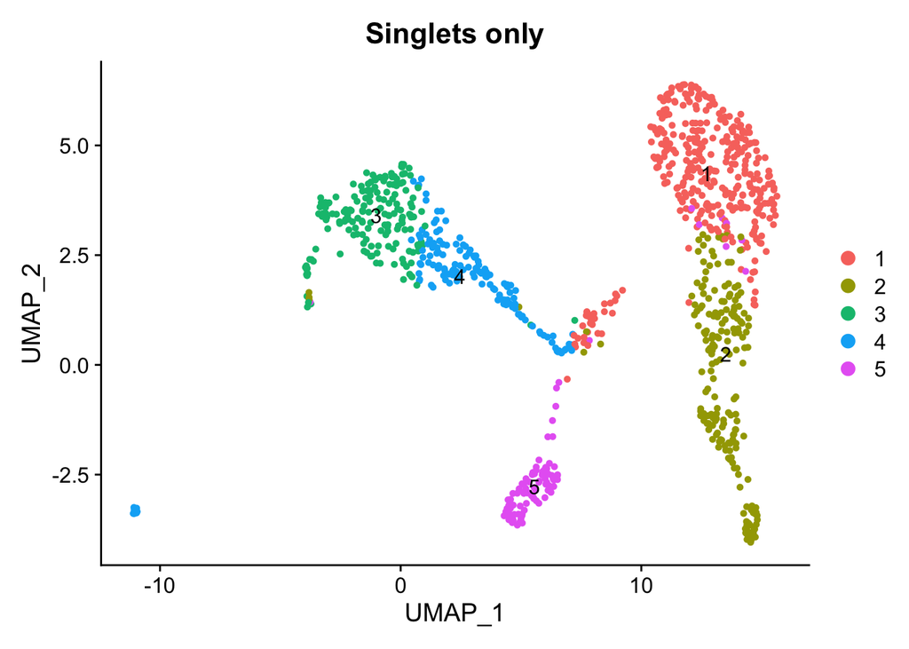

```r
Seurat::DimPlot(pbmc, group.by = "Cluster", label = TRUE) +
  ggplot2::ggtitle("Singlets only")
```

Compare this with the cluster plot above. On a dataset this clean the two will look nearly identical, because only a handful of droplets were removed — which is the correct outcome for a 972-cell capture, not a disappointing one.

> **A caveat about reusing this UMAP.** These coordinates were computed by CellRanger on *all* the droplets, doublets included. Removing cells from a finished embedding is not the same as recomputing it: the doublets influenced where the remaining cells were placed. For a quick look this is fine, and it is the honest way to visualize a before-and-after. But the UMAP you put in a paper should be computed *after* filtering — which is what you will do in Week 3.

Two ordering questions come up immediately, and they have different answers.

## 9.1 Relative to quality-control filtering

Here the package’s advice is clear: **run doublet detection first, then filter on quality.** Two reasons, both worth internalizing:

1. The expected doublet rate is computed from the number of cells you supply. If you have already discarded a third of your cells as low quality, `scDblFinder` is told the capture was smaller than it was and expects fewer doublets than there really are.
2. A doublet formed from one good cell and one dying cell may itself look low-quality. Filter first and you remove it — which sounds fine, except you have then removed it *as a bad cell* rather than identified it as a doublet, and you have deprived the detector of an example.

Two caveats. Empty droplets should already be gone before you start — this is what the *filtered* matrix is for. And extremely low-coverage cells (below a few hundred reads) should be removed, or the internal normalization can fail with a `size factors should be positive` error.

## 9.2 Relative to ambient RNA removal

Here the honest answer is **nobody knows**, and the package authors say so outright. The arguments cut both ways:

- A real doublet can look like contamination — it contains RNA from another cell type, which is exactly what contamination looks like. So a decontamination tool may try to “clean” a doublet, do it imperfectly, and leave behind something no longer detectable as a doublet. That argues for **doublets first**.
- But decontamination makes cells cleaner, which may make the doublet classification problem easier. That argues for **SoupX first**.

There is no published evidence favouring either order. This is not a gap in the tutorial — it is a gap in the field, and the useful response is to say what you did in your methods section rather than to imply a settled convention. If you have the time, running it both ways and checking whether your conclusions move is a legitimate robustness check.

Note that this tutorial deliberately starts from raw counts rather than from the SoupX output, so that it stands alone. Chaining them is one line — the corrected matrix from `adjustCounts()` goes into `CreateSeuratObject()` in place of `pbmc_data[["Gene Expression"]]`.

# 10 What we glossed over

- **Homotypic doublets are essentially invisible here.** Everything above is about heterotypic ones. If you have hashing or SNP-based demultiplexing, those methods catch both kinds and are complementary rather than redundant — expect them to disagree with `scDblFinder`, and know why.
- **We did not verify a single call.** We accepted `scDblFinder.class` without checking whether the flagged droplets behave like doublets. A good check, once you can cluster (Week 3): do the doublets concentrate in one region of the UMAP, and does that region sit *between* two real clusters? A cluster that is overwhelmingly doublets is one you should not be annotating.
- **The default thresholding.** `dbr.sd` controls how much deviation from the expected rate is tolerated; setting `dbr.sd = 1` lets classification accuracy alone drive the threshold. We never touched it.
- **`nfeatures`, `dims`, `iter`.** The number of genes, principal components and training rounds were all defaults.
- **Reproducibility across samples.** `set.seed()` is *not* sufficient when using the `samples` argument, even without parallelism. The seed has to go to the parallel backend: `BPPARAM = SerialParam(RNGseed = 10)`.
- **Whether one method is enough.** The benchmark in the paper found that combining `scDblFinder` with `DoubletFinder` improved results on most datasets, though modestly. Averaging scores across methods is a reasonable thing to do if doublets are central to your conclusions.

# 11 References

- Germain PL, Lun A, Garcia Meixide C, Macnair W, Robinson MD. *Doublet identification in single-cell sequencing data using scDblFinder.* F1000Research 10:979, 2022. [doi:10.12688/f1000research.73600.2](https://doi.org/10.12688/f1000research.73600.2)
- Package vignette: [plger.github.io/scDblFinder](https://plger.github.io/scDblFinder/articles/scDblFinder.html)